# Carbon Emission Insight: Unraveling Climate Impact Patterns

## By: Jasdeep Ahluwalia and Aarti Itikirala

## Research Question:

###### What are the most significant factors influencing CO2 emissions of vehicles, and how can we develop a predictive model to estimate CO2 emissions based on these factors?

### Introduction

Climate change is a critical global issue that affects every aspect of our lives. Greenhouse gases, such as carbon dioxide (CO2), are a significant contributor to this problem. The transportation sector is responsible for a large portion of CO2 emissions, with automotive vehicles playing a major role. As society becomes increasingly aware of the environmental impact of CO2 emissions, it's crucial to understand the factors that influence these emissions from vehicles. This understanding can guide automobile manufacturers, consumers, and policymakers in making informed decisions to reduce CO2 emissions from vehicles.

Data science can be instrumental in helping us identify the key factors that contribute to vehicle CO2 emissions. By analyzing a comprehensive dataset on vehicle features and their corresponding CO2 emissions, we can gain valuable insights into the relationships between these variables. This understanding can guide automobile manufacturers, consumers, and policymakers in making informed decisions to reduce CO2 emissions from vehicles. Additionally, data science enables us to develop predictive models that can estimate CO2 emissions based on vehicle features. These models can be used by automobile manufacturers to design cleaner, more efficient vehicles, and by consumers to make environmentally conscious purchasing decisions.

In this tutorial, we will analyze the "CO2_Emissions_Canada.csv" dataset to answer the research question: "What are the most significant factors influencing CO2 emissions of vehicles, and how can we develop a predictive model to estimate CO2 emissions based on these factors?".

Throughout this tutorial, we will walk you through the entire data science pipeline, including:

1. Data curation, parsing, and management
2. Exploratory data analysis
3. Hypothesis testing
4. Machine learning for predictive analysis
5. Insights and conclusions

By the end of this tutorial, you will have gained a deeper understanding of the relationship between vehicle features and CO2 emissions, and learned how to develop a predictive model to estimate CO2 emissions based on these factors. This knowledge can contribute to the development of cleaner, more efficient vehicles and support informed decision-making to reduce the environmental impact of transportation.

### Step 1: Data Curation, Parsing, and Management

Data curation, parsing, and management are interconnected processes that involve organizing, transforming, and maintaining data to ensure its quality, accessibility, and usability.

- Data curation: The process of organizing, managing, and maintaining data throughout its lifecycle. This includes tasks such as data collection, validation, cleaning, integration, metadata creation, transformation, storage, archiving, access, sharing, documentation, and quality assessment. Data curation aims to improve data quality and ensure its accessibility and usability for various purposes, such as analysis, decision-making, or research.
- Data parsing: The process of analyzing and converting raw data into a structured format that is more easily understood and manipulated by humans or computer programs. Parsing typically involves breaking down data (e.g., text, code, or files) into smaller components or tokens, identifying the structure or relationships among these components, and organizing them into a hierarchical or tabular format. Data parsing is an essential step in data transformation, as it enables data to be more easily processed, analyzed, or integrated with other data sources.
- Data management: The overarching process of controlling and administering data throughout its lifecycle, from creation to storage and eventual disposal. Data management encompasses a wide range of activities, including data governance, data quality assurance, data architecture, data security, data integration, data storage, data backup, and data sharing. Effective data management ensures that data is accurate, consistent, secure, and accessible to support decision-making, analysis, and other data-driven activities.

#### Dataset Overview

The dataset we will be using in this tutorial is "CO2_Emissions_Canada.csv". We found this dataset at: [[https://www.kaggle.com/datasets/debajyotipodder/co2\-emission\-by\-vehicles?select=CO2\+Emissions\_Canada.csv](https://www.kaggle.com/datasets/debajyotipodder/co2-emission-by-vehicles?select=CO2+Emissions_Canada.csv)](https://www.kaggle.com/datasets/debajyotipodder/co2-emission-by-vehicles?select=CO2+Emissions_Canada.csv). This dataset contains information about various vehicle features and their corresponding CO2 emissions.

The dataset includes the following columns:

- Make: The manufacturer of the vehicle.
- Model: The specific model of the vehicle.
- Vehicle Class: The category of the vehicle, such as compact, SUV, or pickup truck.
- Engine Size(L): The size of the engine measured in liters.
- Cylinders: The number of cylinders in the engine.
- Transmission: The type of transmission in the vehicle, such as automatic or manual.
- Fuel Type: The type of fuel the vehicle uses, such as gasoline, diesel, or electric.
- Fuel Consumption City (L/100 km): The fuel consumption in the city measured in liters per 100 kilometers.
- Fuel Consumption Hwy (L/100 km): The fuel consumption on the highway measured in liters per 100 kilometers.
- Fuel Consumption Comb (L/100 km): The combined fuel consumption of a vehicle in liters per 100 kilometers.
- Fuel Consumption Comb (mpg): The combined fuel consumption of a vehicle in mpg.
- CO2 Emissions(g/km): The amount of CO2 emissions produced by the vehicle, measured in grams per kilometer.

#### Data Collection

We are using pandas, numpy, and matplotlib.pyplot.

- Pandas -> used for the DataFrame object since that is an easy way to store tabular data.
- Numpy -> used for its math functionality.
- Seaborn -> used for the ability to easily make heatmaps
- Mathplotlib.pyplot -> used to plot graphs demonstrating relationships between variables in our data.

```python
# Importing necessary libraries
import pandas as pd
import numpy as np
import seaborn as sns
import matplotlib.pyplot as plt
%matplotlib inline
```

```python
df = pd.read_csv("CO2_Emissions_Canada.csv")

df.head()
```

|  | Make | Model | Vehicle Class | Engine Size(L) | Cylinders | Transmission | Fuel Type | Fuel Consumption City (L/100 km) | Fuel Consumption Hwy (L/100 km) | Fuel Consumption Comb (L/100 km) | Fuel Consumption Comb (mpg) | CO2 Emissions(g/km) |
| --- | --- | --- | --- | --- | --- | --- | --- | --- | --- | --- | --- | --- |
| 0 | ACURA | ILX | COMPACT | 2.0 | 4 | AS5 | Z | 9.9 | 6.7 | 8.5 | 33 | 196 |
| 1 | ACURA | ILX | COMPACT | 2.4 | 4 | M6 | Z | 11.2 | 7.7 | 9.6 | 29 | 221 |
| 2 | ACURA | ILX HYBRID | COMPACT | 1.5 | 4 | AV7 | Z | 6.0 | 5.8 | 5.9 | 48 | 136 |
| 3 | ACURA | MDX 4WD | SUV - SMALL | 3.5 | 6 | AS6 | Z | 12.7 | 9.1 | 11.1 | 25 | 255 |
| 4 | ACURA | RDX AWD | SUV - SMALL | 3.5 | 6 | AS6 | Z | 12.1 | 8.7 | 10.6 | 27 | 244 |

#### Data Preprocessing

Before diving into the analysis, we need to preprocess the dataset to ensure that it's clean and ready for further exploration. This involves checking for missing values and converting categorical variables to numerical values.

First we will analyze the categorical variables and after they have been analyzed, we will convert them so that it's easier to analyze the qualitative variables.

#### Handling Missing Values:

Let's first check for any missing values in the dataset:

```python
# Check for missing values
df.isnull().sum()
```

```
Make                                0
Model                               0
Vehicle Class                       0
Engine Size(L)                      0
Cylinders                           0
Transmission                        0
Fuel Type                           0
Fuel Consumption City (L/100 km)    0
Fuel Consumption Hwy (L/100 km)     0
Fuel Consumption Comb (L/100 km)    0
Fuel Consumption Comb (mpg)         0
CO2 Emissions(g/km)                 0
dtype: int64
```

Now, our dataset is ready for further analysis and model development.

### Step 2: Exploratory Data Analysis

Exploratory Data Analysis (EDA) is a crucial step in the data science pipeline, as it helps us gain insights into the dataset's structure, identify potential patterns or relationships, and detect possible outliers or anomalies. In this section, we will perform descriptive statistics on the dataset and create visualizations to explore the distribution of CO2 emissions and relationships with other features.

#### Descriptive Statistics

Let's start by computing the basic descriptive statistics for our dataset, including the mean, standard deviation, minimum, and maximum values for each column:

```python
# Descriptive statistics
df.describe(include=np.number)
```

|  | Engine Size(L) | Cylinders | Fuel Consumption City (L/100 km) | Fuel Consumption Hwy (L/100 km) | Fuel Consumption Comb (L/100 km) | Fuel Consumption Comb (mpg) | CO2 Emissions(g/km) |
| --- | --- | --- | --- | --- | --- | --- | --- |
| count | 7385.000000 | 7385.000000 | 7385.000000 | 7385.000000 | 7385.000000 | 7385.000000 | 7385.000000 |
| mean | 3.160068 | 5.615030 | 12.556534 | 9.041706 | 10.975071 | 27.481652 | 250.584699 |
| std | 1.354170 | 1.828307 | 3.500274 | 2.224456 | 2.892506 | 7.231879 | 58.512679 |
| min | 0.900000 | 3.000000 | 4.200000 | 4.000000 | 4.100000 | 11.000000 | 96.000000 |
| 25% | 2.000000 | 4.000000 | 10.100000 | 7.500000 | 8.900000 | 22.000000 | 208.000000 |
| 50% | 3.000000 | 6.000000 | 12.100000 | 8.700000 | 10.600000 | 27.000000 | 246.000000 |
| 75% | 3.700000 | 6.000000 | 14.600000 | 10.200000 | 12.600000 | 32.000000 | 288.000000 |
| max | 8.400000 | 16.000000 | 30.600000 | 20.600000 | 26.100000 | 69.000000 | 522.000000 |

```python
df.describe(include = object)
```

|  | Make | Model | Vehicle Class | Transmission | Fuel Type |
| --- | --- | --- | --- | --- | --- |
| count | 7385 | 7385 | 7385 | 7385 | 7385 |
| unique | 42 | 2053 | 16 | 27 | 5 |
| top | FORD | F-150 FFV 4X4 | SUV - SMALL | AS6 | X |
| freq | 628 | 32 | 1217 | 1324 | 3637 |

This summary table provides a quick overview of the data distribution for each variable, which can help us identify any unusual values or potential errors in the dataset.

#### Visualizing CO2 Emissions Distribution

To better understand the distribution of CO2 emissions in our dataset, we can create a histogram. We will use the seaborn library in Python to generate this plot.

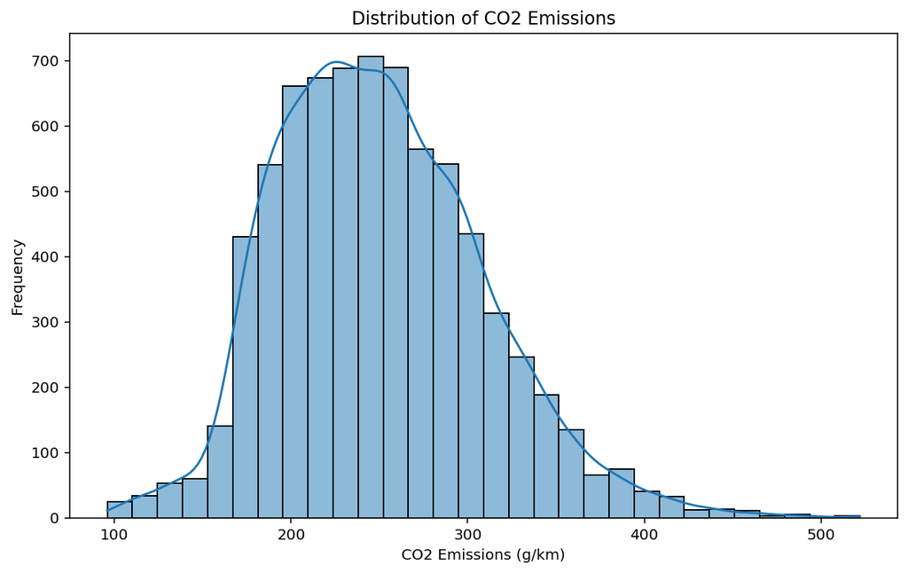

```python
plt.figure(figsize=(10, 6))
sns.histplot(df['CO2 Emissions(g/km)'], kde=True, bins=30)
plt.xlabel('CO2 Emissions (g/km)')
plt.ylabel('Frequency')
plt.title('Distribution of CO2 Emissions')
plt.show()
```

This histogram reveals the distribution of CO2 emissions across the dataset and helps us identify any potential outliers or skewness in the data. From the above histogram, we can see that CO2_Emissions is moderately positive skewed.

#### Analyzing the relationship between CO2 Emissions and Independent Variables

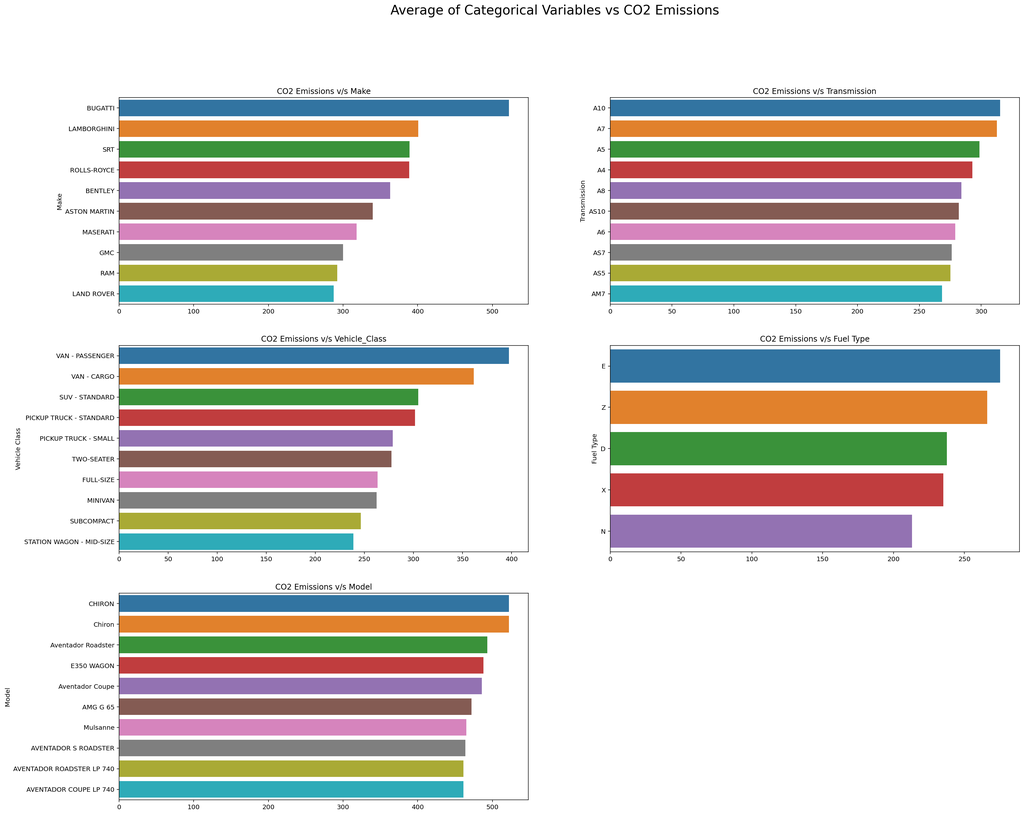

```python
make_co2 = df.groupby('Make')['CO2 Emissions(g/km)'].mean().sort_values(ascending=False).head(10)
model_co2 = df.groupby('Model')['CO2 Emissions(g/km)'].mean().sort_values(ascending=False).head(10)
vehicle_class_co2 = df.groupby('Vehicle Class')['CO2 Emissions(g/km)'].mean().sort_values(ascending=False).head(10)
transmission_co2 = df.groupby('Transmission')['CO2 Emissions(g/km)'].mean().sort_values(ascending=False).head(10)
fuel_type_co2 = df.groupby('Fuel Type')['CO2 Emissions(g/km)'].mean().sort_values(ascending=False).head()
fig, axes = plt.subplots(3,2, figsize=(25,20))
fig.suptitle('Average of Categorical Variables vs CO2 Emissions', size=20)

sns.barplot(ax=axes[0][0],x = make_co2.values,y = make_co2.index)
axes[0][0].set_title('CO2 Emissions v/s Make')

sns.barplot(ax=axes[0][1],x = transmission_co2.values,y = transmission_co2.index)
axes[0][1].set_title('CO2 Emissions v/s Transmission')

sns.barplot(ax=axes[1][0],x = vehicle_class_co2.values,y = vehicle_class_co2.index)
axes[1][0].set_title('CO2 Emissions v/s Vehicle_Class')

sns.barplot(ax=axes[1][1], x=fuel_type_co2.values,y=fuel_type_co2.index)
axes[1][1].set_title('CO2 Emissions v/s Fuel Type')

sns.barplot(ax=axes[2][0],x = model_co2.values,y = model_co2.index)
axes[2][0].set_title('CO2 Emissions v/s Model')


fig.delaxes(axes[2][1])
plt.show()
```

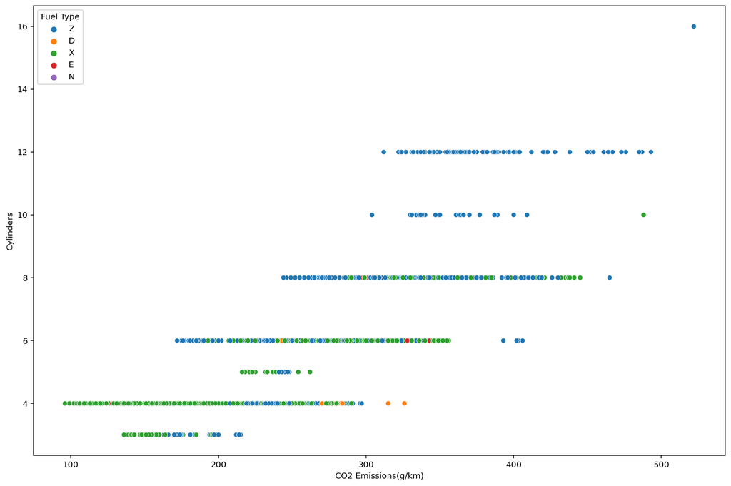

```python
#Relationship between Cylinders and CO2 Emissions
plt.rcParams["figure.figsize"] = (15, 10)
sns.scatterplot(x= 'CO2 Emissions(g/km)', y='Cylinders', data=df, hue='Fuel Type')

plt.xlabel('CO2 Emissions(g/km)', fontsize=10)
plt.ylabel('Cylinders', fontsize=10)

plt.show()
```

From the above scatter plot we can see that:

As the number of cylinders increase, the CO2 emissions increase

Cars with 8 and less than 8 cylinders prefer using Fuel Type X which result in less emissions of CO2

#### Feature Engineering

Create a new feature Type by combining various car companies(Make) on the basis of their functionality

There are 42 Car Companies, that we will now divide into 4 categories: Luxury, Sports, Premium and General cars

```python
# Define regular expressions and corresponding types
pattern_type_mappings = [
    (r'(BUGATTI|PORSCHE|MASERATI|ASTON MARTIN|LAMBORGHINI|JAGUAR|SRT)', 'Sports'),
    (r'(ALFA ROMEO|AUDI|BMW|BUICK|CADILLAC|CHRYSLER|DODGE|GMC|INFINITI|JEEP|LAND ROVER|LEXUS|MERCEDES-BENZ|MINI|SMART|VOLVO)', 'Premium'),
    (r'(ACURA|BENTLEY|LINCOLN|ROLLS-ROYCE|GENESIS)', 'Luxury'),
    (r'(CHEVROLET|FIAT|FORD|KIA|HONDA|HYUNDAI|MAZDA|MITSUBISHI|NISSAN|RAM|SCION|SUBARU|TOYOTA|VOLKSWAGEN)', 'General')
]

# Categorize makes based on patterns
for pattern, make_type in pattern_type_mappings:
    df.loc[df['Make'].str.contains(pattern, regex=True, case=False), 'Make_Type'] = make_type

# Drop rows without a Make_Type assigned
df.dropna(subset=['Make_Type'], inplace=True)

# Drop the 'Make' column
df.drop(['Make'], inplace=True, axis=1)

# Display the first few rows of the DataFrame
print(df.head())
```

```
        Model Vehicle Class  Engine Size(L)  Cylinders Transmission Fuel Type  \
0         ILX       COMPACT             2.0          4          AS5         Z
1         ILX       COMPACT             2.4          4           M6         Z
2  ILX HYBRID       COMPACT             1.5          4          AV7         Z
3     MDX 4WD   SUV - SMALL             3.5          6          AS6         Z
4     RDX AWD   SUV - SMALL             3.5          6          AS6         Z

   Fuel Consumption City (L/100 km)  Fuel Consumption Hwy (L/100 km)  \
0                               9.9                              6.7
1                              11.2                              7.7
2                               6.0                              5.8
3                              12.7                              9.1
4                              12.1                              8.7

   Fuel Consumption Comb (L/100 km)  Fuel Consumption Comb (mpg)  \
0                               8.5                           33
1                               9.6                           29
2                               5.9                           48
3                              11.1                           25
4                              10.6                           27

   CO2 Emissions(g/km) Make_Type
0                  196    Luxury
1                  221    Luxury
2                  136    Luxury
3                  255    Luxury
4                  244    Luxury
```

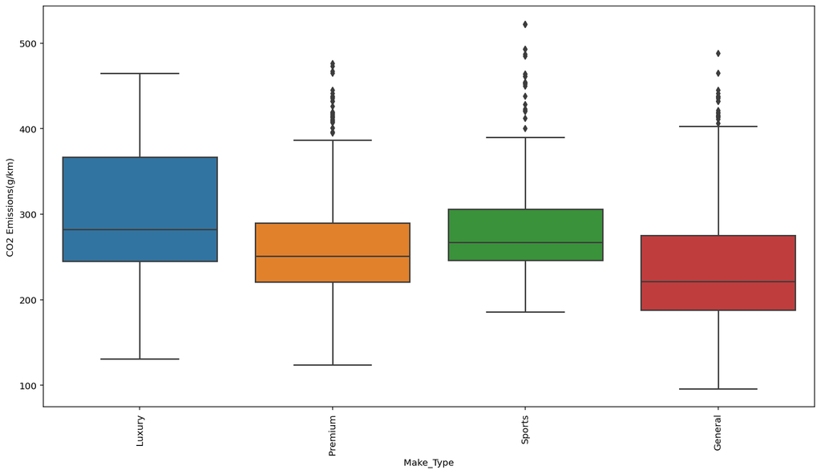

```python
plt.figure(figsize=(15,8))
ax = sns.boxplot(x="Make_Type", y="CO2 Emissions(g/km)", data=df)
ax.set_xticklabels(labels=ax.get_xticklabels(), rotation=90)
plt.show()
```

The plot shows that Sports cars and Luxury cars emit more CO2 compared to Premium and General use cars

Create a new feature Class_Type by combining various Vehicle Class on the basis of their size

There are 16 unique Vehicle Classes, which we will divide into: Hatchback, Sedan, SUV and Truck

```python
df['Class_Type'] = df['Vehicle Class'].replace(['COMPACT', 'MINICOMPACT', 'SUBCOMPACT'], 'Hatchback')
df['Class_Type'] = df['Class_Type'].replace(['MID-SIZE', 'TWO-SEATER', 'FULL-SIZE', 'STATION WAGON - SMALL', 'STATION WAGON - MID-SIZE'],'Sedan')
df['Class_Type'] = df['Class_Type'].replace(['SUV - SMALL', 'SUV - STANDARD', 'MINIVAN'],  'SUV')
df['Class_Type'] = df['Class_Type'].replace(['VAN - CARGO', 'VAN - PASSENGER', 'PICKUP TRUCK - STANDARD', 'SPECIAL PURPOSE VEHICLE', 'PICKUP TRUCK - SMALL'], 'Truck')
```

```python
df['Class_Type'].unique()
```

```
array(['Hatchback', 'SUV', 'Sedan', 'Truck'], dtype=object)
```

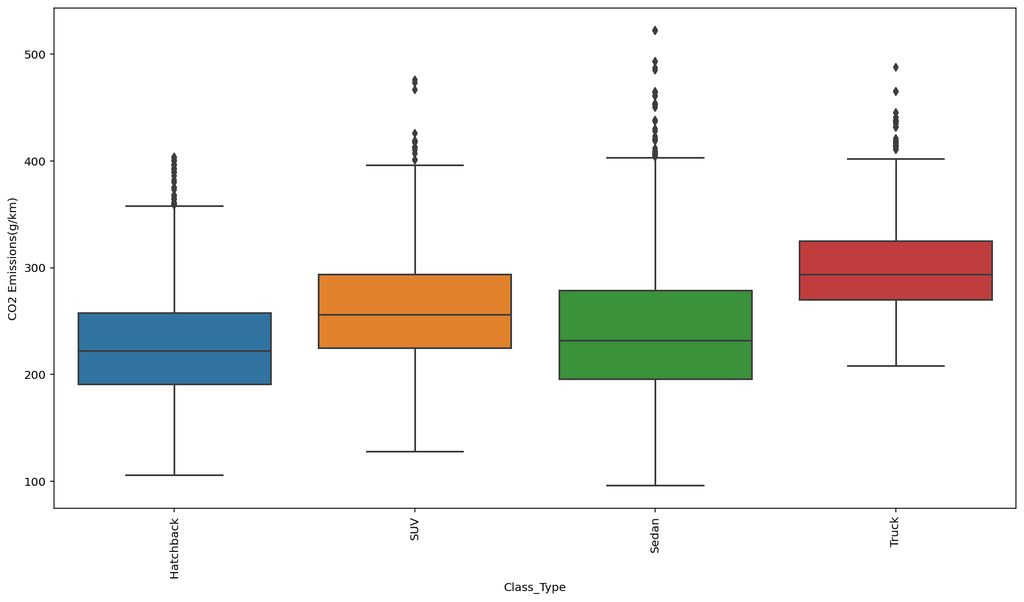

```python
plt.figure(figsize=(15,8))
ax = sns.boxplot(x="Class_Type", y="CO2 Emissions(g/km)", data=df)
ax.set_xticklabels(labels=ax.get_xticklabels(), rotation=90)
plt.show()
```

The plot shows that the bigger the cars are the more CO2 they emit

```python
# Since Model has 2053 unique values and has does not significantly affect CO2 Emissions, we are dropping this column.

df.drop(['Model'],axis=1,inplace=True)

df
```

|  | Vehicle Class | Engine Size(L) | Cylinders | Transmission | Fuel Type | Fuel Consumption City (L/100 km) | Fuel Consumption Hwy (L/100 km) | Fuel Consumption Comb (L/100 km) | Fuel Consumption Comb (mpg) | CO2 Emissions(g/km) | Make_Type | Class_Type |
| --- | --- | --- | --- | --- | --- | --- | --- | --- | --- | --- | --- | --- |
| 0 | COMPACT | 2.0 | 4 | AS5 | Z | 9.9 | 6.7 | 8.5 | 33 | 196 | Luxury | Hatchback |
| 1 | COMPACT | 2.4 | 4 | M6 | Z | 11.2 | 7.7 | 9.6 | 29 | 221 | Luxury | Hatchback |
| 2 | COMPACT | 1.5 | 4 | AV7 | Z | 6.0 | 5.8 | 5.9 | 48 | 136 | Luxury | Hatchback |
| 3 | SUV - SMALL | 3.5 | 6 | AS6 | Z | 12.7 | 9.1 | 11.1 | 25 | 255 | Luxury | SUV |
| 4 | SUV - SMALL | 3.5 | 6 | AS6 | Z | 12.1 | 8.7 | 10.6 | 27 | 244 | Luxury | SUV |
| ... | ... | ... | ... | ... | ... | ... | ... | ... | ... | ... | ... | ... |
| 7380 | SUV - SMALL | 2.0 | 4 | AS8 | Z | 10.7 | 7.7 | 9.4 | 30 | 219 | Premium | SUV |
| 7381 | SUV - SMALL | 2.0 | 4 | AS8 | Z | 11.2 | 8.3 | 9.9 | 29 | 232 | Premium | SUV |
| 7382 | SUV - SMALL | 2.0 | 4 | AS8 | Z | 11.7 | 8.6 | 10.3 | 27 | 240 | Premium | SUV |
| 7383 | SUV - STANDARD | 2.0 | 4 | AS8 | Z | 11.2 | 8.3 | 9.9 | 29 | 232 | Premium | SUV |
| 7384 | SUV - STANDARD | 2.0 | 4 | AS8 | Z | 12.2 | 8.7 | 10.7 | 26 | 248 | Premium | SUV |

7385 rows × 12 columns

#### Converting Categorical Variables

Many machine learning algorithms require numerical input data, so we need to convert categorical variables into numerical ones. In our dataset, we have several categorical columns, such as Make, Vehicle Class, Transmission, and Fuel Type. We can use the cat.codes method from pandas to convert these categorical variables into numerical codes:

```python
categorical_columns = ['Make_Type','Vehicle Class', 'Transmission', 'Fuel Type']
for column in categorical_columns:
    df[column] = df[column].astype('category').cat.codes
```

#### Visualizing Relationships with Other Features

To explore the relationships between CO2 emissions and other features in our dataset, we can create scatter plots. For instance, we can visualize the relationship between CO2 emissions and engine size, fuel consumption (city), and fuel consumption (highway):

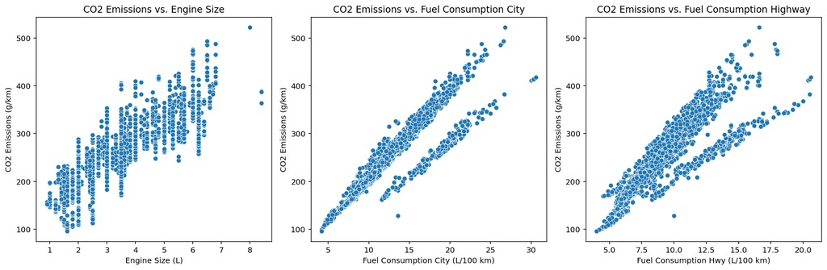

```python
plt.figure(figsize=(15, 5))

# Scatter plot of CO2 emissions vs. engine size
plt.subplot(1, 3, 1)
sns.scatterplot(x=df['Engine Size(L)'], y=df['CO2 Emissions(g/km)'])
plt.xlabel('Engine Size (L)')
plt.ylabel('CO2 Emissions (g/km)')
plt.title('CO2 Emissions vs. Engine Size')

# Scatter plot of CO2 emissions vs. fuel consumption (city)
plt.subplot(1, 3, 2)
sns.scatterplot(x=df['Fuel Consumption City (L/100 km)'], y=df['CO2 Emissions(g/km)'])
plt.xlabel('Fuel Consumption City (L/100 km)')
plt.ylabel('CO2 Emissions (g/km)')
plt.title('CO2 Emissions vs. Fuel Consumption City')

# Scatter plot of CO2 emissions vs. fuel consumption (highway)
plt.subplot(1, 3, 3)
sns.scatterplot(x=df['Fuel Consumption Hwy (L/100 km)'], y=df['CO2 Emissions(g/km)'])
plt.xlabel('Fuel Consumption Hwy (L/100 km)')
plt.ylabel('CO2 Emissions (g/km)')
plt.title('CO2 Emissions vs. Fuel Consumption Highway')

plt.tight_layout()
plt.show()
```

These scatter plots allow us to identify potential correlations or trends between CO2 emissions and other vehicle features, which will be useful when developing our predictive model in the next section.

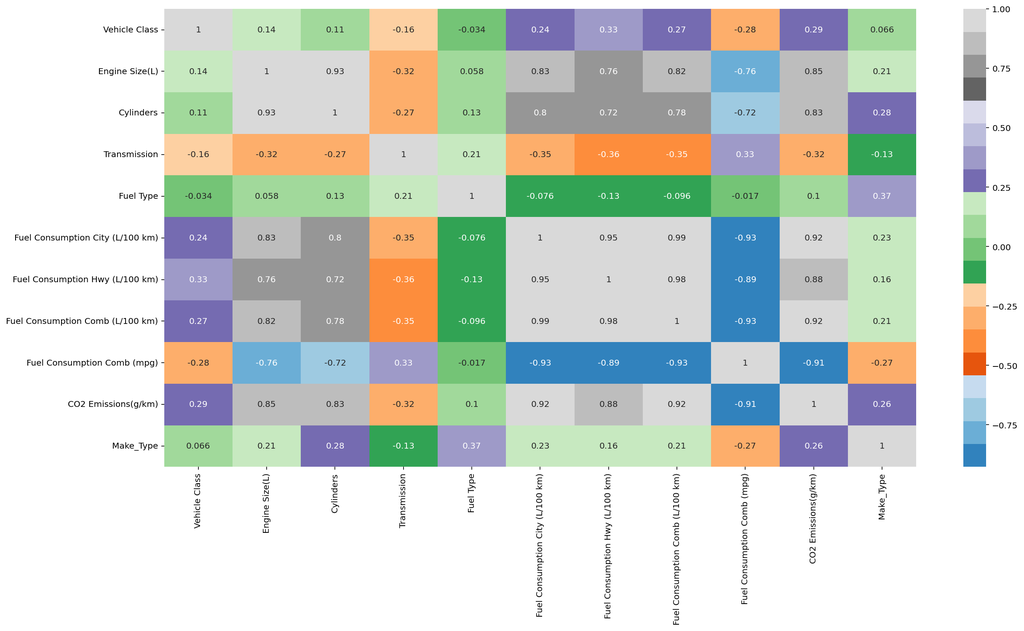

```python
plt.figure(figsize=(20,10))

corr =  (df.select_dtypes(include=np.number)).corr()

corr =(df.select_dtypes(include=np.number)).corr(method='pearson')
sns.heatmap(corr, annot=True,cmap='tab20c')
plt.show()
```

Observations:

- Fuel_Consumption_Comb1 has a high negative correaltion(<-0.9) with CO2_Emissions, Fuel_Consumption_Comb and Fuel_Consumption_City
- CO2_Emissions has high positive correlation(>0.9) with Fuel_Consumption_Comb and Fuel_Consumption_City

### Step 3: Hypothesis Testing

Hypothesis testing is a statistical method that allows us to make inferences about the population based on sample data. In this section, we will formulate null and alternative hypotheses related to our research question and conduct appropriate statistical tests to verify or reject the null hypothesis.

#### Formulating Hypotheses

Based on our research question, "What are the most significant factors influencing CO2 emissions of vehicles?", we can formulate the following null and alternative hypotheses:

- Null hypothesis (H0): There is no significant relationship between the vehicle features and CO2 emissions.

- Alternative hypothesis (H1): There is a significant relationship between at least one of the vehicle features and CO2 emissions.

We will use multiple linear regression to conduct our hypothesis test, as we are interested in understanding the relationship between multiple independent variables (vehicle features) and a continuous dependent variable (CO2 emissions).

#### Conducting the Hypothesis Test

To perform the multiple linear regression, we will use the `statsmodels` library in Python.

Now, let's fit a multiple linear regression model and obtain the summary statistics:

```python
import statsmodels.api as sm

# Define the dependent variable (y) and independent variables (X)
y = df['CO2 Emissions(g/km)']
X = df.select_dtypes(include=[np.number])  # Select only numeric columns
X = X.drop(['CO2 Emissions(g/km)'], axis=1)  # Remove the dependent variable from the independent variables

# Add a constant term to the independent variables (X)
X = sm.add_constant(X)


# Fit the multiple linear regression model
model = sm.OLS(y, X).fit()

# Obtain the model summary
model.summary()
```

OLS Regression Results

| Dep. Variable: | CO2 Emissions(g/km) | R-squared: | 0.917 |
| --- | --- | --- | --- |
| Model: | OLS | Adj. R-squared: | 0.916 |
| Method: | Least Squares | F-statistic: | 8104. |
| Date: | Fri, 12 May 2023 | Prob (F-statistic): | 0.00 |
| Time: | 17:32:28 | Log-Likelihood: | -31357. |
| No. Observations: | 7385 | AIC: | 6.274e+04 |
| Df Residuals: | 7374 | BIC: | 6.281e+04 |
| Df Model: | 10 |  |  |
| Covariance Type: | nonrobust |  |  |

|  | coef | std err | t | P>\|t\| | [0.025 | 0.975] |
| --- | --- | --- | --- | --- | --- | --- |
| const | 166.3144 | 4.445 | 37.420 | 0.000 | 157.602 | 175.027 |
| Vehicle Class | 0.6872 | 0.045 | 15.213 | 0.000 | 0.599 | 0.776 |
| Engine Size(L) | 4.9485 | 0.433 | 11.421 | 0.000 | 4.099 | 5.798 |
| Cylinders | 6.1019 | 0.310 | 19.691 | 0.000 | 5.494 | 6.709 |
| Transmission | -0.0624 | 0.030 | -2.054 | 0.040 | -0.122 | -0.003 |
| Fuel Type | 7.7979 | 0.270 | 28.901 | 0.000 | 7.269 | 8.327 |
| Fuel Consumption City (L/100 km) | -0.7780 | 2.553 | -0.305 | 0.761 | -5.782 | 4.226 |
| Fuel Consumption Hwy (L/100 km) | 1.4590 | 2.111 | 0.691 | 0.489 | -2.679 | 5.597 |
| Fuel Consumption Comb (L/100 km) | 7.1967 | 4.635 | 1.553 | 0.121 | -1.890 | 16.283 |
| Fuel Consumption Comb (mpg) | -2.7253 | 0.078 | -35.056 | 0.000 | -2.878 | -2.573 |
| Make_Type | -1.7745 | 0.208 | -8.511 | 0.000 | -2.183 | -1.366 |

| Omnibus: | 767.333 | Durbin-Watson: | 1.592 |
| --- | --- | --- | --- |
| Prob(Omnibus): | 0.000 | Jarque-Bera (JB): | 4765.543 |
| Skew: | 0.294 | Prob(JB): | 0.00 |
| Kurtosis: | 6.891 | Cond. No. | 1.09e+03 |

Notes:  
[1] Standard Errors assume that the covariance matrix of the errors is correctly specified.  
[2] The condition number is large, 1.09e+03. This might indicate that there are  
strong multicollinearity or other numerical problems.

Here we will analyze the p-values and coefficients of each independent variable:

Vehicle Class:

- The coefficient is 0.6872, which suggests a positive relationship with CO2 emissions. The p-value is very low (p < 0.001), indicating a highly significant effect on CO2 emissions.

Engine Size(L):

- The coefficient is 4.9485, indicating a positive relationship with CO2 emissions. The p-value is very low (p < 0.001), indicating a highly significant effect on CO2 emissions.

Cylinders:

- The coefficient is 6.1019, suggesting a positive relationship with CO2 emissions. The p-value is very low (p < 0.001), indicating a highly significant effect on CO2 emissions.

Transmission:

- The coefficient is -0.0624, indicating a negative relationship with CO2 emissions. The p-value is 0.040, which is statistically significant (p < 0.05), but relatively less significant compared to other variables.

Fuel Type:

- The coefficient is 7.7979, suggesting a positive relationship with CO2 emissions. The p-value is very low (p < 0.001), indicating a highly significant effect on CO2 emissions.

Fuel Consumption City (L/100 km):

- The coefficient is -0.7780, indicating a negative relationship with CO2 emissions. However, the p-value is relatively high (p = 0.761), suggesting that the effect may not be statistically significant.

Fuel Consumption Hwy (L/100 km):

- The coefficient is 1.4590, suggesting a positive relationship with CO2 emissions. However, the p-value is relatively high (p = 0.489), suggesting that the effect may not be statistically significant.

Fuel Consumption Comb (L/100 km):

- The coefficient is 7.1967, suggesting a positive relationship with CO2 emissions. The p-value is 0.121, which is relatively higher than the standard significance level (p < 0.05), indicating that the effect may not be statistically significant.

Fuel Consumption Comb (mpg):

- The coefficient is -2.7253, indicating a negative relationship with CO2 emissions. The p-value is very low (p < 0.001), indicating a highly significant effect on CO2 emissions.

Make_Type:

- The coefficient is -1.7745, indicating a negative relationship with CO2 emissions. The p-value is very low (p < 0.001), indicating a highly significant effect on CO2 emissions.

### Step 4: Machine Learning For Predictive Analysis

#### Developing a Linear Regression Model

We will use the `scikit-learn` library in Python to create our linear regression model.

```python
from sklearn.model_selection import train_test_split
from sklearn.linear_model import LinearRegression

# Define the significant features and the dependent variable
X = df[['Engine Size(L)', 'Cylinders', 'Fuel Consumption Comb (L/100 km)']]
y = df['CO2 Emissions(g/km)']

# Split the data into training and testing sets
X_train, X_test, y_train, y_test = train_test_split(X, y, test_size=0.2, random_state=42)

# Fit the linear regression model
lr_model = LinearRegression()
lr_model.fit(X_train, y_train)

# Print the linear regression model
intercept = lr_model.intercept_
coefficients = lr_model.coef_

eq = f"y = {intercept:.2f}"
for i, coef in enumerate(coefficients):
    eq += f" + {coef:.2f}x{i+1}"
print(eq)

# Make predictions on the test set
y_pred = lr_model.predict(X_test)
```

```
y = 51.53 + 5.59x1 + 6.38x2 + 13.27x3
```

To evaluate our linear regression model, we will calculate the mean squared error (MSE), root mean squared error (RMSE), and R2 score:

```python
from sklearn.metrics import mean_squared_error, r2_score

# Calculate the mean squared error
mse = mean_squared_error(y_test, y_pred)

# Calculate the root mean squared error
rmse = np.sqrt(mse)

# Calculate the R2 score
r2 = r2_score(y_test, y_pred)

print(f'Mean Squared Error: {mse:.2f}')
print(f'Root Mean Squared Error: {rmse:.2f}')
print(f'R2 Score: {r2:.2f}')
```

```
Mean Squared Error: 421.92
Root Mean Squared Error: 20.54
R2 Score: 0.88
```

These metrics provide an indication of how well our model performs in predicting CO2 emissions based on the selected features.

#### Visualizing Actual vs. Predicted CO2 Emissions

To visualize the actual vs. predicted CO2 emissions, we can create a scatter plot:

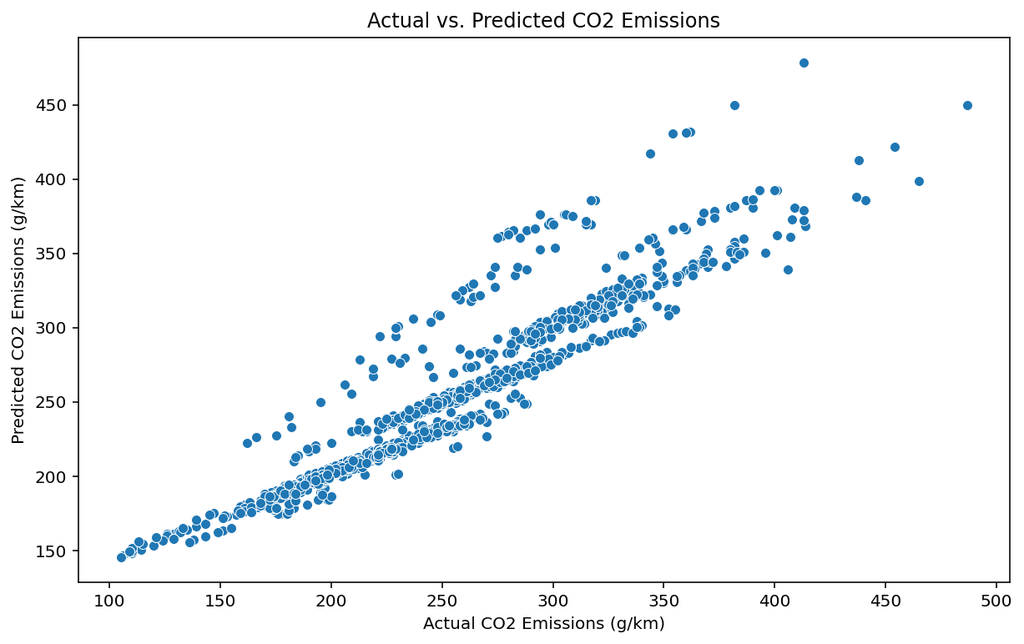

```python
plt.figure(figsize=(10, 6))
sns.scatterplot(x=y_test, y=y_pred)
plt.xlabel('Actual CO2 Emissions (g/km)')
plt.ylabel('Predicted CO2 Emissions (g/km)')
plt.title('Actual vs. Predicted CO2 Emissions')
plt.show()
```

Ideally, the points should lie along a diagonal line, indicating perfect agreement between the actual and predicted values.

#### Visualizing Residuals Plot

A residuals plot can help us assess the quality of our model by showing the distribution of the residuals (the difference between the actual and predicted values). A good model should have residuals that are randomly distributed around zero:

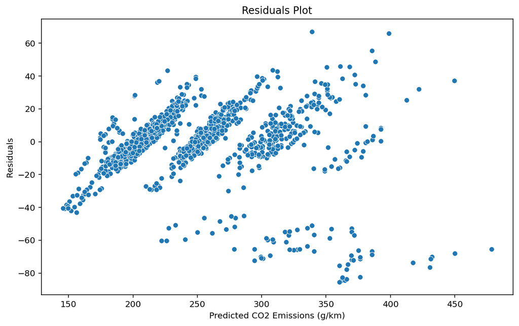

```python
residuals = y_test - y_pred

plt.figure(figsize=(10, 6))
sns.scatterplot(x=y_pred,y=residuals)
plt.xlabel('Predicted CO2 Emissions (g/km)')
plt.ylabel('Residuals')
plt.title('Residuals Plot')
plt.show()
```

If the residuals are randomly distributed around zero and show no clear pattern, this indicates that our model is well-fitted and captures the underlying structure of the data.

#### Discussing Feature Importance

We can interpret the coefficients of the linear regression model to determine the importance of each feature in predicting CO2 emissions. Larger absolute values of coefficients indicate a stronger relationship between the feature and the target variable:

```python
feature_importance = pd.DataFrame({'Feature': X.columns, 'Coefficient': lr_model.coef_})
feature_importance = feature_importance.sort_values(by='Coefficient', ascending=False)
feature_importance
```

|  | Feature | Coefficient |
| --- | --- | --- |
| 2 | Fuel Consumption Comb (L/100 km) | 13.270330 |
| 1 | Cylinders | 6.380798 |
| 0 | Engine Size(L) | 5.594713 |

This table displays the coefficients for each significant feature in our model, which can help us understand the impact of each feature on CO2 emissions.

Remember that the actual significant features may vary depending on the dataset and the results of the hypothesis testing section. Always refer to the p-values obtained during hypothesis testing to select the appropriate features for the linear regression model.

### Implications and Contributions

Our findings can contribute to the development of cleaner and more efficient vehicles by providing insights into the factors that have the greatest impact on CO2 emissions. Manufacturers can use this information to focus on optimizing these specific factors when designing and producing new vehicles. Furthermore, our predictive model can serve as a tool for estimating CO2 emissions based on vehicle features, which can be valuable for consumers, policymakers, and environmental organizations in making informed decisions.

### Future Work and Improvements

1. Incorporate additional data sources and features to enhance the analysis and improve the predictive model.
2. Explore other machine learning models and feature selection techniques to improve the accuracy of the predictions.
3. Investigate the potential impact of other factors, such as driving conditions, vehicle maintenance, and weather, on CO2 emissions.
4. Extend the analysis to include other pollutants and environmental impacts, providing a more comprehensive understanding of the environmental footprint of vehicles.

By continuing to refine and expand our analysis, we can contribute to a better understanding of the factors influencing vehicle CO2 emissions, ultimately helping to reduce the environmental impact of transportation.

## Conclusion

In this tutorial, we have gone through the entire data science pipeline, from data curation and parsing to exploratory data analysis, hypothesis testing, and machine learning. Our goal was to answer the research question: "What are the most significant factors influencing CO2 emissions of vehicles, and how can we develop a predictive model to estimate CO2 emissions based on these factors?".

After going through this process, we have come to identify that out of all of our variables, the following have the most significant impact on CO2 Emissions:

- Fuel Consumption Comb (L/100 km):
  - This variable has the highest coefficient of 13.270330, indicating that it has the most significant impact on predicting CO2 emissions.
- Cylinders:
  - The variable "Cylinders" has a coefficient of 6.380798, indicating a strong influence on predicting CO2 emissions.
- Engine Size(L):
  - The variable "Engine Size(L)" has a coefficient of 5.594713, suggesting it is also an important factor in predicting CO2 emissions.

This indicates that "Fuel Consumption Comb (L/100 km)" has the highest importance in predicting CO2 emissions, followed by "Cylinders" and "Engine Size(L)". Higher absolute coefficient values signify stronger relationships between the independent variable and the target variable.